# Task 3 (Files and Exceptions) - Assignment

# Name: Hammond Helen

### Date: February 11th 2023

Follow the instructions in 9.12.3 (starting pg. 346).

Don't work in interactive mode!

Instead complete the exercise in a notebook.

# 1 - Load

1-Load: Use pandas to read in the Titanic Disaster dataset csv file. If you have a URL representing a CSV dataset, you can load it into a DataFrame with read_csv. Let’s load the Titanic Disaster dataset directly from GitHub

```python
import pandas as pd

titanic = pd.read_csv('https://vincentarelbundock.github.io/Rdatasets/csv/carData/TitanicSurvival.csv')
```

2-View: Set the precision to 2 decimal places. View the head and tail of the file.

# 2 - View

```python
pd.options.display.precision = 2 # format the floating point values to 2 decimal places

titanic.head() #View the first 5 entries in the file
```

|  | Unnamed: 0 | survived | sex | age | passengerClass |
| --- | --- | --- | --- | --- | --- |
| 0 | Allen, Miss. Elisabeth Walton | yes | female | 29.00 | 1st |
| 1 | Allison, Master. Hudson Trevor | yes | male | 0.92 | 1st |
| 2 | Allison, Miss. Helen Loraine | no | female | 2.00 | 1st |
| 3 | Allison, Mr. Hudson Joshua Crei | no | male | 30.00 | 1st |
| 4 | Allison, Mrs. Hudson J C (Bessi | no | female | 25.00 | 1st |

```python
titanic.tail(10) #View the first 10 entries in the file
```

|  | Unnamed: 0 | survived | sex | age | passengerClass |
| --- | --- | --- | --- | --- | --- |
| 1299 | Yasbeck, Mr. Antoni | no | male | 27.0 | 3rd |
| 1300 | Yasbeck, Mrs. Antoni (Selini Al | yes | female | 15.0 | 3rd |
| 1301 | Youseff, Mr. Gerious | no | male | 45.5 | 3rd |
| 1302 | Yousif, Mr. Wazli | no | male | NaN | 3rd |
| 1303 | Yousseff, Mr. Gerious | no | male | NaN | 3rd |
| 1304 | Zabour, Miss. Hileni | no | female | 14.5 | 3rd |
| 1305 | Zabour, Miss. Thamine | no | female | NaN | 3rd |
| 1306 | Zakarian, Mr. Mapriededer | no | male | 26.5 | 3rd |
| 1307 | Zakarian, Mr. Ortin | no | male | 27.0 | 3rd |
| 1308 | Zimmerman, Mr. Leo | no | male | 29.0 | 3rd |

3-Headings: customize the column headings.

# 3 - Headings

The first column in this dataset has a strange name ('Unnamed: 0'). We can clean that up by setting the column names. Let’s change 'Unnamed: 0' to 'name' and let’s shorten 'passengerClass' to 'class':

```python
titanic.columns = ['name', 'survived', 'sex', 'age', 'class']
titanic.head()
```

|  | name | survived | sex | age | class |
| --- | --- | --- | --- | --- | --- |
| 0 | Allen, Miss. Elisabeth Walton | yes | female | 29.00 | 1st |
| 1 | Allison, Master. Hudson Trevor | yes | male | 0.92 | 1st |
| 2 | Allison, Miss. Helen Loraine | no | female | 2.00 | 1st |
| 3 | Allison, Mr. Hudson Joshua Crei | no | male | 30.00 | 1st |
| 4 | Allison, Mrs. Hudson J C (Bessi | no | female | 25.00 | 1st |

4-Describe: Use the DataFrame describe() function to calculate basic descriptive statistics for all numeric columns.

# 4 - Describe

For example, let’s look at some descriptive statistics. When you call describe on a DataFrame containing both numeric and non-numeric columns, describe calculates these statistics only for the numeric columns—in this case, just the age column:

```python
titanic.describe()
```

|  | age |
| --- | --- |
| count | 1046.00 |
| mean | 29.88 |
| std | 14.41 |
| min | 0.17 |
| 25% | 21.00 |
| 50% | 28.00 |
| 75% | 39.00 |
| max | 80.00 |

5-Survivors: Follow instructions to describe statistics for those who survived (titanic.survived == 'yes') - see the example.

# 5 - Survivors

Let’s say you want to determine some statistics about people who survived. We can compare the survived column to 'yes' to get a new Series containing True/False values, then use describe to summarize the results:

```python
(titanic.survived == 'yes').describe()
```

```
count      1309
unique        2
top       False
freq        809
Name: survived, dtype: object
```

Notice that describe provides different results for non-numeric data (e.g., unique, top, freq)

For non-numeric data, describe displays different descriptive statistics:

- `count` is the total number of items in the result.
- `unique` is the number of unique values (2) in the result—True (survived) and False (died).
- `top` is the most frequently occurring value in the result.
- `freq` is the number of occurrences of the top value.

6-Histogram: Use the DataFrame's hist() function to create a histogram for each numerical column.

# 6 - Histogram

Visualization is a nice way to get to know your data. Pandas has many built-in visualization capabilities that are implemented with Matplotlib. To use them, first enable Matplotlib support in IPython:

```python
%matplotlib inline
```

A histogram visualizes the distribution of numerical data over a range of values. A DataFrame’s hist method automatically analyzes each numerical column’s data and produces a corresponding histogram. To view histograms of each numerical data column, call hist on your DataFrame:

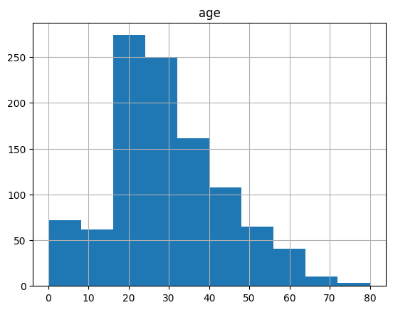

```python
histogram = titanic.hist()
```

Required: Use Section headings in your Markdown to make it clear that each of these 6 sections are shown in your notebook. They should be numbered 1-6 and include the keyword shown above.

Required: Include the title of the notebook, and your name and date at the top.

Do these consistently. A heading and section titles is required in every notebook.